# ISLR 6: Exercises

# Conceptual

## Question 1

We perform best subset, forward stepwise, and backward stepwise selection on a single data set. For each approach, we obtain $p + 1$ models, containing $0, 1, 2, \dots, p$ predictors. Explain your answers:

**(a)** Which of the three models with $k$ predictors has the smallest *training* RSS? By construction, best subset selection has the smallest training RSS; it is *defined* as the $k$-predictor model with lowest RSS; the other two are bound to previously chosen predictors if $k \neq 1$

**(b)** Which of the three models with $k$ predictors has the smallest test RSS? There’s no way to tell. Best subset might be the one if the test data is somewhat similar to the training data, but just out of luck, any one might be better with the training data.

**(c)** True or False: **i.** The predictors in the $k$-variable model identified by forward stepwise are a subset of the predictors in the $(k+1)$-variable model identified by forward stepwise selection. True. The $(k+1)$-variable model is obtained by iterating over all unused predictors and choosing the one that improves the model. **ii.**The predictors in the $k$-variable model identified by backward stepwise are a subset of the predictors in the $(k+1)$-variable model identified by backward stepwise selection. True. The least important one is removed. **iii.** The predictors in the $k$-variable model identified by backward stepwise are a subset of the predictors in the $(k+1)$-variable model identified by forward stepwise selection. False. It would only be the case if a low p-value (important in backward selection) corresponded to lowering RMSE (important in forward selection) which is not always the case. **iv.** The predictors in the $k$-variable model identified by forward stepwise are a subset of the predictors in the $(k+1)$-variable model identified by backward stepwise selection. False. There is no reason why this would be necessary the case unless what stated in (iii) were true. **v.** The predictors in the $k$-variable model identified by best subset are a subset of the predictors in the $(k+1)$-variable model identified by best subset selection. False. Among other things, correlation between variables can cause a variable in the $k$-variable model to become redundant in the $k+1$ model.

## Question 2

For parts (a) through (c), indicate which of i. through iv. is correct. Justify your answer.

**(a)** The lasso, relative to least squares, is less flexible and hence will give improved prediction accuracy  
when its increase in bias is less than its decrease in variance. **(b)** Ridge regression, relative to least squares, is less flexible and hence will give improved prediction accuracy when its increase in bias is less than its decrease in variance. **(c)** Non-linear methods, relative to least squares, are more flexible and hence will give improved prediction accuracy when their increase in variance is less than their decrease in bias.

## Question 3

Suppose we estimate the regression coefficients in a linear regression model by minimizing
$$\sum_{i=1}^n \left( y_i-\beta_0-\sum_{j=1}^p \beta_j x_{ij} \right)^2 \\ \\
\text{subject to} \ \ \|\beta\|_1 \leq s$$
for a particular value of s. For parts (a) through (e), indicate which of i. through v. is correct. Justify your answer.

**(a)** As we increase s from 0, the training RSS will steadily decrease; as $s \rightarrow \infty$, $\beta^L \rightarrow \beta$, where $\beta$ is the least squares coefficient vector. **(b)** As we increase s from 0, the test RSS will decrease initially, and then eventually start increasing in a U shape, because at first the increase in bias will be less than the decrease in variance. **(c)** As we increase s from 0, the variance will steadily increase. **(d)** As we increase s from 0, the squared bias will steadily decrease **(e)** As we increase s from 0, the training irreducible error will remain constant.

## Question 4

Suppose we estimate the regression coefficients in a linear regression model by minimizing
$$\sum_{i=1}^n \left( y_i-\beta_0-\sum_{j=1}^p \beta_j x_{ij} \right)^2 + \lambda \|\beta\|_2^2$$
for a particular value of $\lambda$. For parts (a) through (e), indicate which of i. through v. is correct. Justify your answer.

**(a)** As we increase $\lambda$ from 0, the training RSS will steadily increase. When $\lambda = 0$ we have plain least squares regression with the optmal training RSS; so increasing the penalty on the coefficients will also increase training RSS. **(b)** As we increase $\lambda$ from 0, the test RSS will will decrease initially, and then eventually start increasing in a U shape, because at first the increase in bias will be less than the decrease in variance. **(c)** As we increase $\lambda$ from 0, the variance will steadily decrease. **(d)** As we increase $\lambda$ from 0, the squared bias will steadily increase. **(e)** As we increase $\lambda$ from 0, the training irreducible error will remain constant.

## Question 5

It is well-known that ridge regression tends to give similar coefficient values to correlated variables, whereas the lasso may give quite different coefficient values to correlated variables. We will now explore this property in a very simple setting.

Suppose that $n = 2, \ p = 2, \ x_{11} = x_{12}, x_{21} = x_{22}$. Furthermore, supposethat $y_1+y_2 =0$ and $x_{11}+x_{21} =0$ and $x_{12}+x_{22} =0$, so that the estimate for the intercept in a least squares, ridge regression, or lasso model is zero: $\hat{\beta_0} = 0$. **(a)** Write out the ridge regression optimization problem in this setting. For simplicity, let $x_1 = x_{11} = x_{12}$, let $x_2 = x_{21} = x_{22}$. Wee seek to solve
$$\min \{ (y_1-x_1(\beta_1+\beta_2))^2 + (y_2-x_2(\beta_1+\beta_2))^2 + \lambda(\beta_1^2+\beta_2^2) \}$$
**(b)** Argue that in this setting, the ridge coefficient estimates satisfy $\hat{\beta_1} = \hat{\beta_2}$ Let $f: \mathbb{R}^2 \to \mathbb{R}$as to rewrite the problem as $\min_\beta f(\beta)$. It is easy to see that
$$f_{\beta_1} = 2(y_1-x_1(\beta_1+\beta_2))(-x_1) + 2(y_2-x_2(\beta_1+\beta_2))(-x_2) + 2\lambda\beta_1$$
and
$$f_{\beta_2} = 2(y_1-x_1(\beta_1+\beta_2))(-x_1) + 2(y_2-x_2(\beta_1+\beta_2))(-x_2) + 2\lambda\beta_2$$
Thus, substracting both expresions, $2\lambda(\beta_1-\beta_2)=0$ and the result follows.

**(c)** Write out the lasso optimization problem in this setting.
$$\min \min \{ (y_1-x_1(\beta_1+\beta_2))^2 + (y_2-x_2(\beta_1+\beta_2))^2 \\
\text{subject to} \ \ \|\beta\|_1 \leq s_\lambda$$
**(d)** Argue that in this setting, the lasso coefficients are not unique. It is easy to see that the solution to the unconstrained optimization problem is $\{\beta \in \mathbb{R^2} : \beta_1+\beta_2= \frac{y_1}{x_1}$ More so, because of the given conditions on $\bf{x}$ and $\bf{y}$, this is equivalent to minimizing $g(\beta) = y_1^2+x_1^2(\beta_1+\beta_2)$, a function whose level sets are two parallel lines with slope -1. Thus, the solution is the intersection of these two sets, which are the two negatively sloped edges of the $\|\cdot\|_1$-ball.

## Question 6

We will now explore (6.12) and (6.13) further. **(a)**Consider (6.12) with $p = 1$. For some choice of $y_1$ and $\lambda>0$, plot (6.12) as a function of $\beta_1$ Your plot should confirm that (6.12) is solved by (6.14).

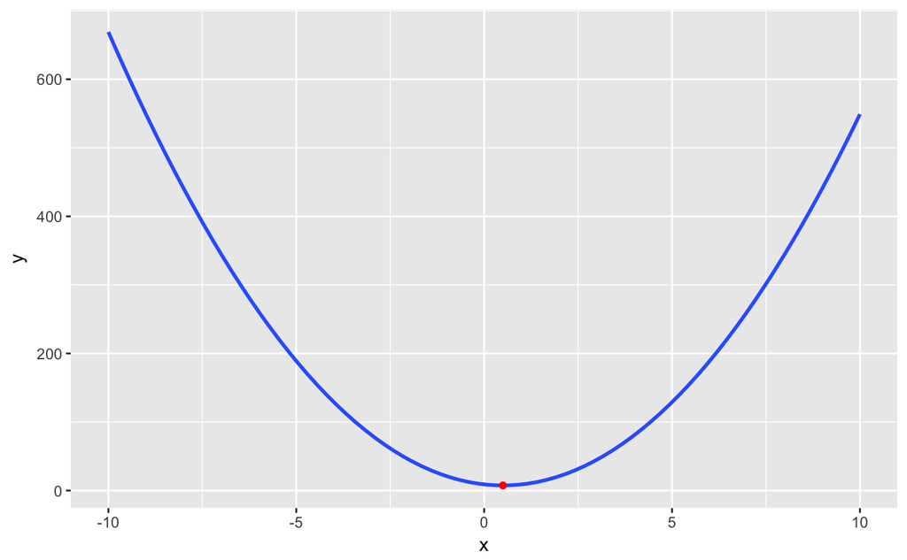

```r
y <- 3
lambda <- 5
beta <- seq(from = -10, to = 10, by = 0.1)
theo_sol <- y/(1+lambda)
ridge <- (y-beta)^2 + lambda*beta^2
ggplot(data_frame(x = beta, y = ridge), aes(x = x, y = y)) +
  geom_smooth() +
  geom_point(data = data_frame(x = theo_sol, y = (y-theo_sol)^2 + lambda*theo_sol^2), col = 'red')
```

**(b)** Consider (6.13) with $p = 1$. For some choice of $y_1$ and $\lambda>0$, plot (6.13) as a function of $\beta_1$ Your plot should confirm that (6.13) is solved by (6.15).

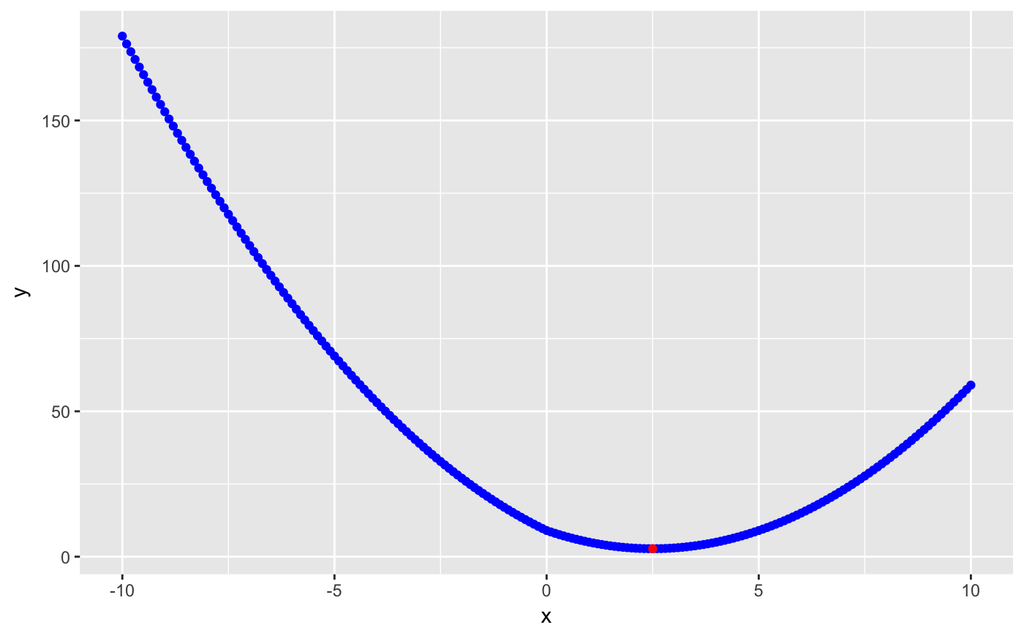

```r
y <- 3
lambda <- 1
beta <- seq(from = -10, to = 10, by = 0.1)
theo_sol <- y - lambda/2
lasso <- (y-beta)^2 + lambda*abs(beta)
ggplot(data_frame(x = beta, y = lasso), aes(x = x, y = y)) +
  geom_point(col = 'blue') +
  geom_point(data = data_frame(x = theo_sol, y = (y-theo_sol)^2 + lambda*abs(theo_sol)), col = 'red')
```

# Applied

## Question 8

In this exercise, we will generate simulated data, and will then use this data to perform best subset selection. **(a)** Use the `rnorm()` function to generate a predictor X of length n = 100, as well as a noise vector ε of length $n = 100$.

```r
x <- rnorm(100)
```

**(b)** Generate a response vector Y of length $n = 100$ using a third degree polynomial of your choice and some error.

```r
y <- 5 - 3*x + pi*x^2 + x^3 + rnorm(100)
```

```r
data <- data_frame(x = x, y = y)
rfe_control <- rfeControl(functions = lmFuncs,
                          method = 'repeatedcv',
                          number = 10,
                          repeats = 5)
data_mm <- model.matrix(y~poly(x, degree = 10), data = data)[,-1]
caret_fit <- rfe(data_mm,
                 y = data$y,
                 sizes = c(1:10),
                 rfeControl = rfe_control)
```

[output not shown]